# Course Project Machine Learning

The aim of this project is to use data from accelerometers on the belt, forearm, arm, and dumbell to predict the manner in which participants of the study did the their barbell lifts. Response variable is the *“classe”* variable in the dataset.

Tasks are:

1. To develop an algorithm to predict *“classe”*
2. To use cross validation to estimate the out of sample error
3. To predict 20 different test cases

At the beginning necessary libraries and both training and test datasets are loaded

```r
library("caret")
library("kernlab")
library("pls")
library("ipred")
library("plyr")


pmltrain <- read.csv("pml-training.csv",header=T)
pmltest <- read.csv("pml-testing.csv",header=T)
dim(pmltrain)
```

```
## [1] 19622   160
```

The dataset contains a lot of variables. To reduce the number of variables we first find out which of them have almost zero variance and sort them out.

```r
nzv <- nearZeroVar(pmltrain,saveMetrics=T)
rem <- which(nzv$nzv == TRUE)
pmltrain <- pmltrain[,-rem]
pmltest <- pmltest[,-rem]
dim(pmltrain)
```

```
## [1] 19622   100
```

There are still a lot of variables left. Lets have a look at them.

```r
summary(pmltrain)
```

```
##        X            user_name    raw_timestamp_part_1 raw_timestamp_part_2
##  Min.   :    1   adelmo  :3892   Min.   :1.322e+09    Min.   :   294
##  1st Qu.: 4906   carlitos:3112   1st Qu.:1.323e+09    1st Qu.:252912
##  Median : 9812   charles :3536   Median :1.323e+09    Median :496380
##  Mean   : 9812   eurico  :3070   Mean   :1.323e+09    Mean   :500656
##  3rd Qu.:14717   jeremy  :3402   3rd Qu.:1.323e+09    3rd Qu.:751891
##  Max.   :19622   pedro   :2610   Max.   :1.323e+09    Max.   :998801
##
##           cvtd_timestamp    num_window      roll_belt
##  28/11/2011 14:14: 1498   Min.   :  1.0   Min.   :-28.90
##  05/12/2011 11:24: 1497   1st Qu.:222.0   1st Qu.:  1.10
##  30/11/2011 17:11: 1440   Median :424.0   Median :113.00
##  05/12/2011 11:25: 1425   Mean   :430.6   Mean   : 64.41
##  02/12/2011 14:57: 1380   3rd Qu.:644.0   3rd Qu.:123.00
##  02/12/2011 13:34: 1375   Max.   :864.0   Max.   :162.00
##  (Other)         :11007
##    pitch_belt          yaw_belt       total_accel_belt max_roll_belt
##  Min.   :-55.8000   Min.   :-180.00   Min.   : 0.00    Min.   :-94.300
##  1st Qu.:  1.7600   1st Qu.: -88.30   1st Qu.: 3.00    1st Qu.:-88.000
##  Median :  5.2800   Median : -13.00   Median :17.00    Median : -5.100
##  Mean   :  0.3053   Mean   : -11.21   Mean   :11.31    Mean   : -6.667
##  3rd Qu.: 14.9000   3rd Qu.:  12.90   3rd Qu.:18.00    3rd Qu.: 18.500
##  Max.   : 60.3000   Max.   : 179.00   Max.   :29.00    Max.   :180.000
##                                                        NA's   :19216
##  max_picth_belt  min_roll_belt     min_pitch_belt  amplitude_roll_belt
##  Min.   : 3.00   Min.   :-180.00   Min.   : 0.00   Min.   :  0.000
##  1st Qu.: 5.00   1st Qu.: -88.40   1st Qu.: 3.00   1st Qu.:  0.300
##  Median :18.00   Median :  -7.85   Median :16.00   Median :  1.000
##  Mean   :12.92   Mean   : -10.44   Mean   :10.76   Mean   :  3.769
##  3rd Qu.:19.00   3rd Qu.:   9.05   3rd Qu.:17.00   3rd Qu.:  2.083
##  Max.   :30.00   Max.   : 173.00   Max.   :23.00   Max.   :360.000
##  NA's   :19216   NA's   :19216     NA's   :19216   NA's   :19216
##  amplitude_pitch_belt var_total_accel_belt avg_roll_belt
##  Min.   : 0.000       Min.   : 0.000       Min.   :-27.40
##  1st Qu.: 1.000       1st Qu.: 0.100       1st Qu.:  1.10
##  Median : 1.000       Median : 0.200       Median :116.35
##  Mean   : 2.167       Mean   : 0.926       Mean   : 68.06
##  3rd Qu.: 2.000       3rd Qu.: 0.300       3rd Qu.:123.38
##  Max.   :12.000       Max.   :16.500       Max.   :157.40
##  NA's   :19216        NA's   :19216        NA's   :19216
```

[output cut: 169 more lines]

```
##  Min.   :-498.00   Min.   :-632.0   Min.   :-446.00   Min.   :-1280.0
##  1st Qu.:-178.00   1st Qu.:  57.0   1st Qu.:-182.00   1st Qu.: -616.0
##  Median : -57.00   Median : 201.0   Median : -39.00   Median : -378.0
##  Mean   : -61.65   Mean   : 163.7   Mean   : -55.29   Mean   : -312.6
##  3rd Qu.:  76.00   3rd Qu.: 312.0   3rd Qu.:  26.00   3rd Qu.:  -73.0
##  Max.   : 477.00   Max.   : 923.0   Max.   : 291.00   Max.   :  672.0
##
##  magnet_forearm_y magnet_forearm_z classe
##  Min.   :-896.0   Min.   :-973.0   A:5580
##  1st Qu.:   2.0   1st Qu.: 191.0   B:3797
##  Median : 591.0   Median : 511.0   C:3422
##  Mean   : 380.1   Mean   : 393.6   D:3216
##  3rd Qu.: 737.0   3rd Qu.: 653.0   E:3607
##  Max.   :1480.0   Max.   :1090.0
##
```

A number of variables has many NAs. Imputation doesn't make sense so we will exclude those variables with more than 50% missings.

```r
traindf <- pmltrain[ , sapply(pmltrain, function(x) mean(is.na(x))<0.5)]
testdf <- pmltest[ , sapply(pmltest, function(x) mean(is.na(x))<0.5)]
dim(traindf)
```

```
## [1] 19622    59
```

```r
str(traindf)
```

```
## 'data.frame':    19622 obs. of  59 variables:
##  $ X                   : int  1 2 3 4 5 6 7 8 9 10 ...
##  $ user_name           : Factor w/ 6 levels "adelmo","carlitos",..: 2 2 2 2 2 2 2 2 2 2 ...
##  $ raw_timestamp_part_1: int  1323084231 1323084231 1323084231 1323084232 1323084232 1323084232 1323084232 1323084232 1323084232 1323084232 ...
##  $ raw_timestamp_part_2: int  788290 808298 820366 120339 196328 304277 368296 440390 484323 484434 ...
##  $ cvtd_timestamp      : Factor w/ 20 levels "02/12/2011 13:32",..: 9 9 9 9 9 9 9 9 9 9 ...
##  $ num_window          : int  11 11 11 12 12 12 12 12 12 12 ...
##  $ roll_belt           : num  1.41 1.41 1.42 1.48 1.48 1.45 1.42 1.42 1.43 1.45 ...
##  $ pitch_belt          : num  8.07 8.07 8.07 8.05 8.07 8.06 8.09 8.13 8.16 8.17 ...
##  $ yaw_belt            : num  -94.4 -94.4 -94.4 -94.4 -94.4 -94.4 -94.4 -94.4 -94.4 -94.4 ...
##  $ total_accel_belt    : int  3 3 3 3 3 3 3 3 3 3 ...
##  $ gyros_belt_x        : num  0 0.02 0 0.02 0.02 0.02 0.02 0.02 0.02 0.03 ...
##  $ gyros_belt_y        : num  0 0 0 0 0.02 0 0 0 0 0 ...
##  $ gyros_belt_z        : num  -0.02 -0.02 -0.02 -0.03 -0.02 -0.02 -0.02 -0.02 -0.02 0 ...
##  $ accel_belt_x        : int  -21 -22 -20 -22 -21 -21 -22 -22 -20 -21 ...
```

[output cut: 45 more lines]

The *cvtd_timestamp* variable is a factor with 20 levels. We will remove it and then create dummy variables for all the other factor variables in the dataset.

```r
traindf <- traindf[,-5]
testdf <- testdf[,-5]

dvars <- dummyVars(classe ~ .,data=traindf)
dummytrain <- predict(dvars, newdata=traindf)
dummytrain <- data.frame(dummytrain,traindf$classe)

dvars2 <- dummyVars(~ .,data=testdf)
dummytest <- predict(dvars2, newdata=testdf)
dummytest <- data.frame(dummytest[,1:62])
```

Now that we have converted all factor variables to dummy variables we calculate principle components to reduce the number of variables.

```r
preProcess(dummytrain[,-63],method="pca",thresh=0.8)
```

```
##
## Call:
## preProcess.default(x = dummytrain[, -63], method = "pca", thresh = 0.8)
##
## Created from 19622 samples and 62 variables
## Pre-processing: principal component signal extraction, scaled, centered
##
## PCA needed 13 components to capture 80 percent of the variance
```

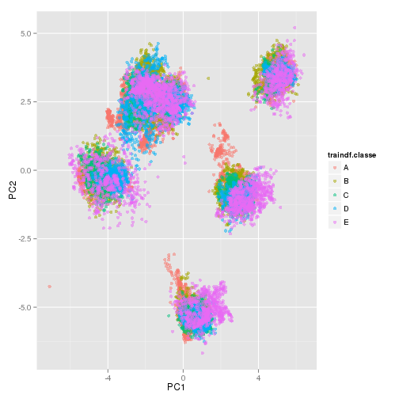

```r
PreProc <- preProcess(dummytrain[,-63],method="pca",pcaComp=13)
pcatrain <- predict(PreProc,dummytrain[,-63])
pcatrain <- data.frame(traindf$classe,pcatrain)
g <- ggplot(pcatrain,aes(x=PC1,y=PC2,color=traindf.classe)) + geom_point(alpha=0.5)
g
```

```r
pcatest <- predict(PreProc,dummytest[,])
```

```r
ctrl <- trainControl(method = "repeatedcv",repeats = 5)

modelfit1 <- train(traindf.classe ~.,data=pcatrain,method="pls",trControl = ctrl)
modelfit1
```

```
## Partial Least Squares
##
## 19622 samples
##    13 predictors
##     5 classes: 'A', 'B', 'C', 'D', 'E'
##
## No pre-processing
## Resampling: Cross-Validated (10 fold, repeated 5 times)
##
## Summary of sample sizes: 17660, 17660, 17661, 17658, 17659, 17660, ...
##
## Resampling results across tuning parameters:
##
##   ncomp  Accuracy   Kappa      Accuracy SD  Kappa SD
##   1      0.3783815  0.1834962  0.005167034  0.006707363
##   2      0.4168792  0.2337899  0.005194132  0.006791400
##   3      0.4510455  0.2810323  0.006718323  0.008872602
##
## Accuracy was used to select the optimal model using  the largest value.
## The final value used for the model was ncomp = 3.
```

```r
modelfit2 <- train(traindf.classe ~.,data=pcatrain,method="treebag",trControl = ctrl)
modelfit2
```

```
## Bagged CART
##
## 19622 samples
##    13 predictors
##     5 classes: 'A', 'B', 'C', 'D', 'E'
##
## No pre-processing
## Resampling: Cross-Validated (10 fold, repeated 5 times)
##
## Summary of sample sizes: 17659, 17659, 17660, 17659, 17660, 17660, ...
##
## Resampling results
##
##   Accuracy  Kappa      Accuracy SD  Kappa SD
##   0.959087  0.9482498  0.004333552  0.005479015
##
##
```

```r
modelfit3 <- train(traindf.classe ~.,data=pcatrain,method="svmRadial",trControl = ctrl)
modelfit3
```

```
## Support Vector Machines with Radial Basis Function Kernel
##
## 19622 samples
##    13 predictors
##     5 classes: 'A', 'B', 'C', 'D', 'E'
##
## No pre-processing
## Resampling: Cross-Validated (10 fold, repeated 5 times)
##
## Summary of sample sizes: 17659, 17661, 17659, 17660, 17661, 17659, ...
##
## Resampling results across tuning parameters:
##
##   C     Accuracy   Kappa      Accuracy SD  Kappa SD
##   0.25  0.8755880  0.8425425  0.007095723  0.008972291
##   0.50  0.8996735  0.8730382  0.006417413  0.008125258
##   1.00  0.9187644  0.8972310  0.006001373  0.007588454
##
## Tuning parameter 'sigma' was held constant at a value of 0.0517259
## Accuracy was used to select the optimal model using  the largest value.
## The final values used for the model were sigma = 0.0517259 and C = 1.
```

```r
confusionMatrix(pcatrain$traindf.classe,predict(modelfit3,pcatrain))
```

```
## Confusion Matrix and Statistics
##
##           Reference
## Prediction    A    B    C    D    E
##          A 5424  108   42    5    1
##          B  195 3279  294    9   20
##          C    9  153 3209   42    9
##          D    7   18  270 2904   17
##          E    5   23   63  174 3342
##
## Overall Statistics
##
##                Accuracy : 0.9254
##                  95% CI : (0.9216, 0.929)
##     No Information Rate : 0.2874
##     P-Value [Acc > NIR] : < 2.2e-16
##
##                   Kappa : 0.9056
##  Mcnemar's Test P-Value : < 2.2e-16
##
## Statistics by Class:
##
##                      Class: A Class: B Class: C Class: D Class: E
## Sensitivity            0.9617   0.9157   0.8275   0.9266   0.9861
## Specificity            0.9888   0.9677   0.9865   0.9811   0.9837
## Pos Pred Value         0.9720   0.8636   0.9378   0.9030   0.9265
## Neg Pred Value         0.9846   0.9809   0.9587   0.9860   0.9971
## Prevalence             0.2874   0.1825   0.1976   0.1597   0.1727
## Detection Rate         0.2764   0.1671   0.1635   0.1480   0.1703
## Detection Prevalence   0.2844   0.1935   0.1744   0.1639   0.1838
## Balanced Accuracy      0.9753   0.9417   0.9070   0.9538   0.9849
```

```r
testclasse <- predict(modelfit3,pcatest)
testclasse
```

```
##  [1] A A A A A A A A A A A A A A E A A A A B
## Levels: A B C D E
```